# THE COVID-19 PANDEMIC IN GEORGIA

D.B Joseph

2022-10-06

# 1. Introduction

Georgia (Georgian: საქართველო, romanized: Sakartvelo; IPA: [sɑkʰɑrtʰvɛlɔ] (listen)) is a transcontinental country at the intersection of Eastern Europe and Western Asia. It is part of the Caucasus region, bounded by the Black Sea to the west, by Russia to the north and east, by Turkey to the southwest, by Armenia to the south, and by Azerbaijan to the southeast. The country covers an area of 69,700 square kilometres (26,900 sq mi), and has a population of 3.7 million people.[b][9] Tbilisi is its capital as well as its largest city, home to roughly a third of the Georgian population.

During the classical era, several independent kingdoms became established in what is now Georgia, such as Colchis and Iberia. In the early 4th century, ethnic Georgians officially adopted Christianity, which contributed to the spiritual and political unification of the early Georgian states. In the Middle Ages, the unified Kingdom of Georgia emerged and reached its Golden Age during the reign of King David IV and Queen Tamar in the 12th and early 13th centuries. Thereafter, the kingdom declined and eventually disintegrated under the hegemony of various regional powers, including the Mongols, the Timurids, the Ottoman Empire, and the successive dynasties of Persia. In 1783, one of the Georgian kingdoms entered into an alliance with the Russian Empire, which proceeded to annex the territory of modern Georgia in a piecemeal fashion throughout the 19th century.

After the Russian Revolution in 1917, Georgia emerged as an independent republic under German protection.[10] Following World War I, Georgia was invaded and annexed by the Soviet Union in 1922, becoming one of its constituent republics. By the 1980s, an independence movement emerged and grew quickly, leading to Georgia’s secession from the Soviet Union in April 1991. For most of the subsequent decade, post-Soviet Georgia suffered from economic crisis, political instability, ethnic conflict, and secessionist wars in Abkhazia and South Ossetia. Following the bloodless Rose Revolution in 2003, Georgia strongly pursued a pro-Western foreign policy; it introduced a series of democratic and economic reforms aimed at integration into the European Union and NATO. The country’s Western orientation soon led to worsening relations with Russia, which culminated in the Russo-Georgian War of 2008; Russia has since been occupying a portion of Georgia.

Georgia is a representative democracy governed as a unitary parliamentary republic.[11][12] It is a developing country with a very high human development. Economic reforms since independence have led to higher levels of economic freedom, as well as reductions in corruption indicators, poverty, and unemployment. It was one of the first countries in the world to legalize cannabis, becoming the only former-socialist state to do so. The country is a member of international organizations across Europe and Asia, such as the Council of Europe, the OSCE, Eurocontrol, the EDRB, the BSCE, the GUAM, the ADB, the WTO, and the Energy Community.

## location

Georgia, a country at the intersection of Europe and Asia, is a former Soviet republic that’s home to Caucasus Mountain villages and Black Sea beaches. It’s famous for Vardzia, a sprawling cave monastery dating to the 12th century, and the ancient wine-growing region Kakheti. The capital, Tbilisi, is known for the diverse architecture and mazelike, cobblestone streets of its old town.

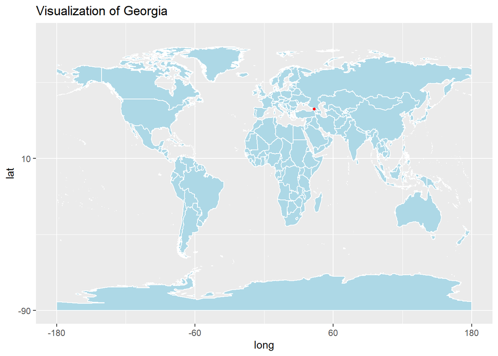

Figure 1: Location of Georgia.

## Climate

In the western part of Georgia the climate is subtropical, while in the eastern part experiences a dry moderate continental climate. Annual precipitation in Georgia ranges from 400 to 4,500 mm. Due to its location at a relatively low latitude and moderate cloudiness, Georgia receives significant heat from the sun.

# 2. Exploratory Data Analysis

Considering the coronavirus analysis of Goergia, there are main facts to be consider. They are,

- Confirmed cases
- Death cases
- Recovered cases

In this coronavirus data set, we are considering incidents happened from 22.01.2020 to 23.06.2022 range.

```
      date              province           country               lat
 Min.   :2020-01-22   Length:2652        Length:2652        Min.   :42.32
 1st Qu.:2020-08-29   Class :character   Class :character   1st Qu.:42.32
 Median :2021-04-07   Mode  :character   Mode  :character   Median :42.32
 Mean   :2021-04-07                                         Mean   :42.32
 3rd Qu.:2021-11-14                                         3rd Qu.:42.32
 Max.   :2022-06-23                                         Max.   :42.32

      long           type               cases              uid
 Min.   :43.36   Length:2652        Min.   :    0.0   Min.   :268
 1st Qu.:43.36   Class :character   1st Qu.:    0.0   1st Qu.:268
 Median :43.36   Mode  :character   Median :   18.0   Median :268
 Mean   :43.36                      Mean   :  779.7   Mean   :268
 3rd Qu.:43.36                      3rd Qu.:  552.5   3rd Qu.:268
 Max.   :43.36                      Max.   :26320.0   Max.   :268
                                    NA's   :1
     iso2               iso3               code3     combined_key
 Length:2652        Length:2652        Min.   :268   Length:2652
 Class :character   Class :character   1st Qu.:268   Class :character
 Mode  :character   Mode  :character   Median :268   Mode  :character
                                       Mean   :268
                                       3rd Qu.:268
                                       Max.   :268

   population      continent_name     continent_code
 Min.   :3989175   Length:2652        Length:2652
 1st Qu.:3989175   Class :character   Class :character
 Median :3989175   Mode  :character   Mode  :character
 Mean   :3989175
 3rd Qu.:3989175
 Max.   :3989175
```

### 2.1 Confirmed Data of Georgia.

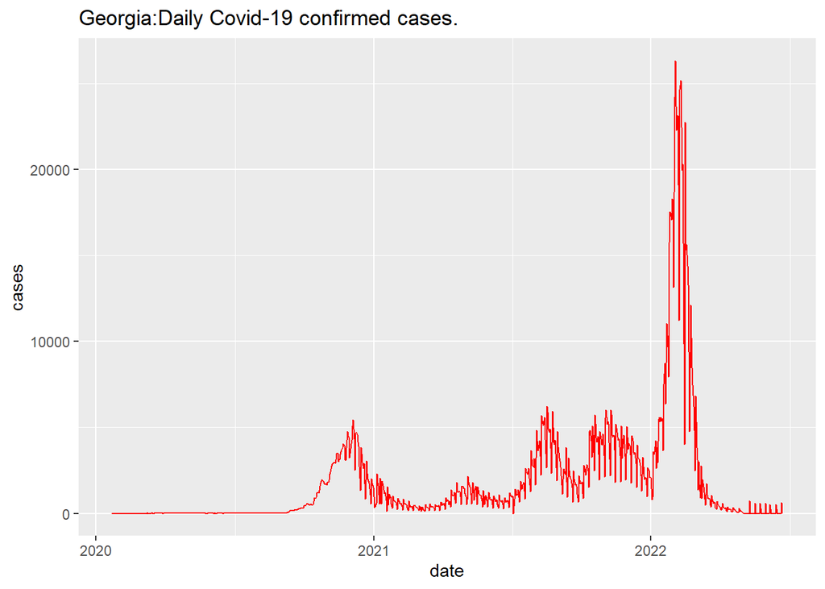

Figure 2: Time series plot of coronavirus confirmed cases.

The above figure 2 shows the number of daily COVID-19 confirmed cases in Georgia from 22.01.2020 tO 23.06.2022.According to that we can see that the number of Covid cases confirmed in the year 2020 is very low. After that it was increased and the maximum number of confirmed cases reported on 2022.

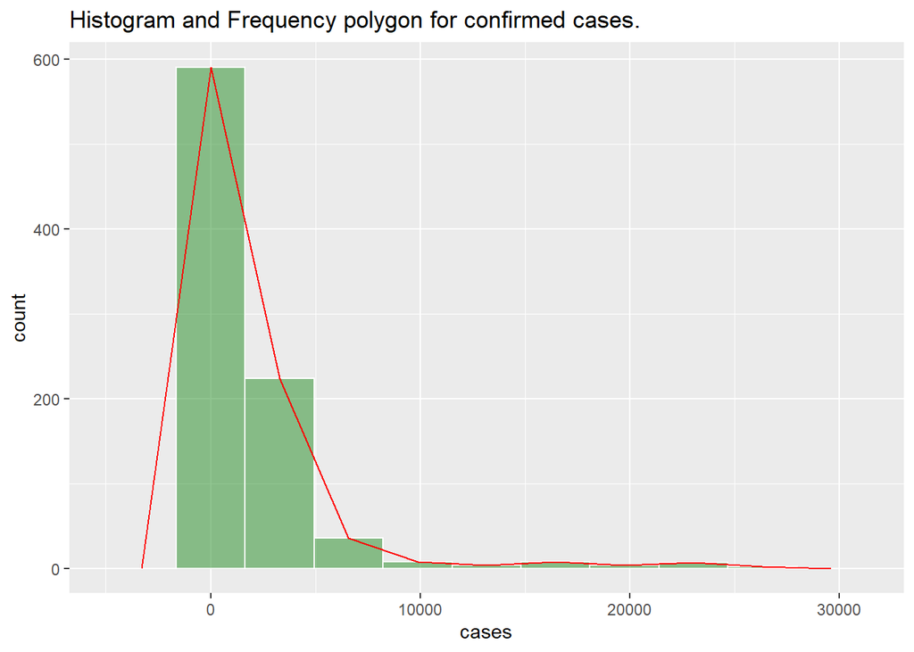

Figure 3:Distribution of number of coronavirus confirmed cases.

### 2.2 Recovered Data of Georgia.

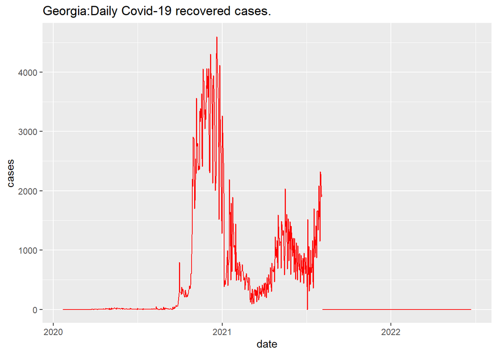

Figure 4: Time series plot of recovered cases.

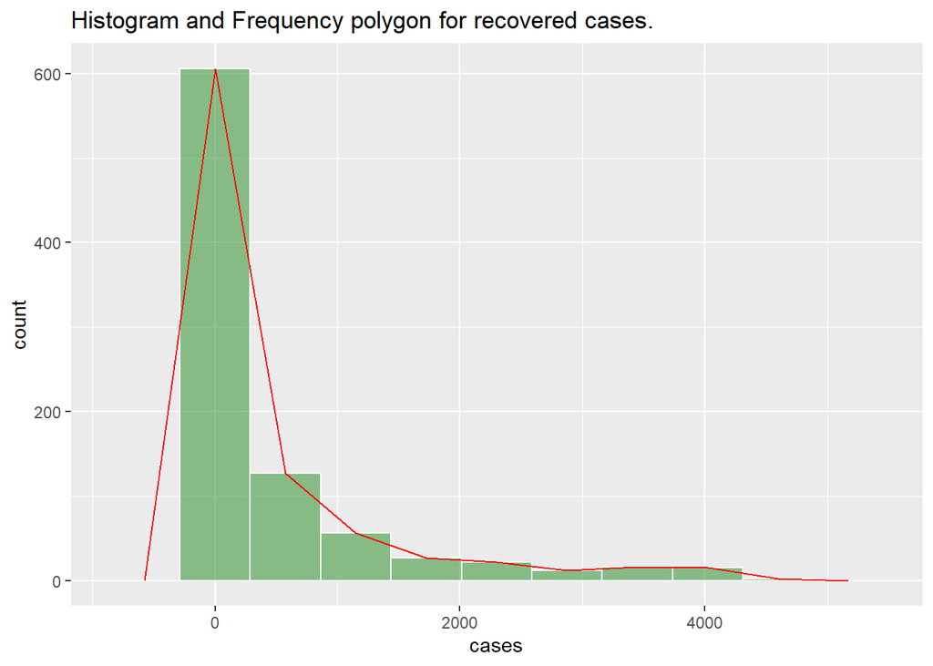

Figure 5:Distribution of number of coronavirus recovered cases.

Considering between 22.01.2020 to 23.06.2022 period, it can be seen that majority days recovered below about 1500 corona virus confirmed patients per day.

### 2.3 Deaths Data of Georgia.

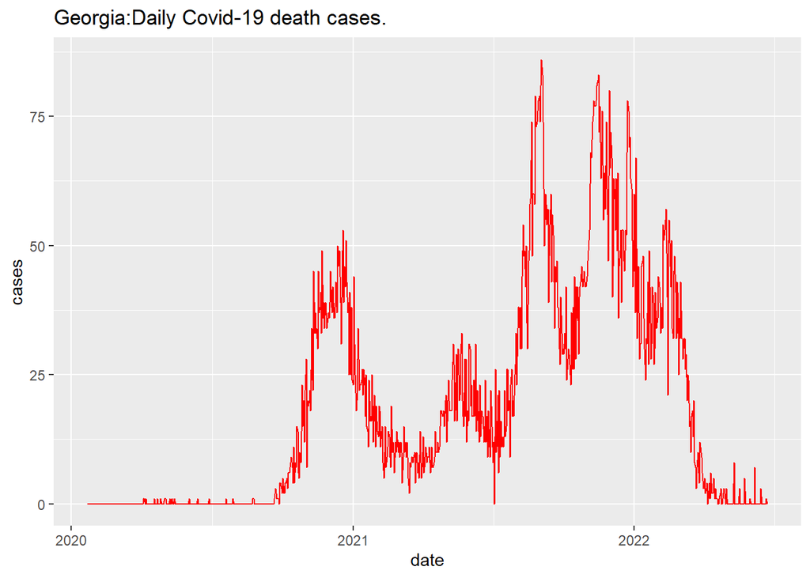

Figure 6: Time series plot of death cases.

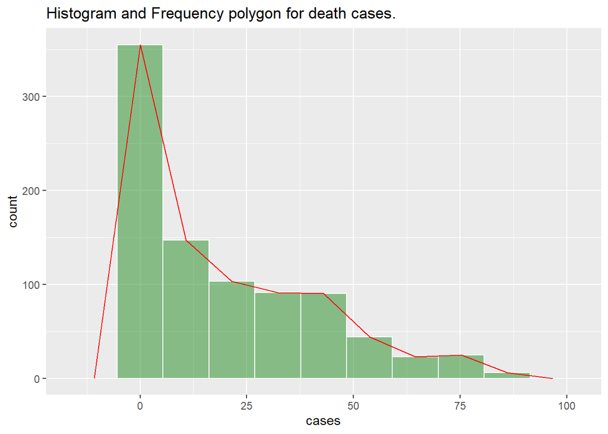

Figure 7: Distribution of number of coronavirus deaths.

### 2.4 Comparison of Coronavirus data.

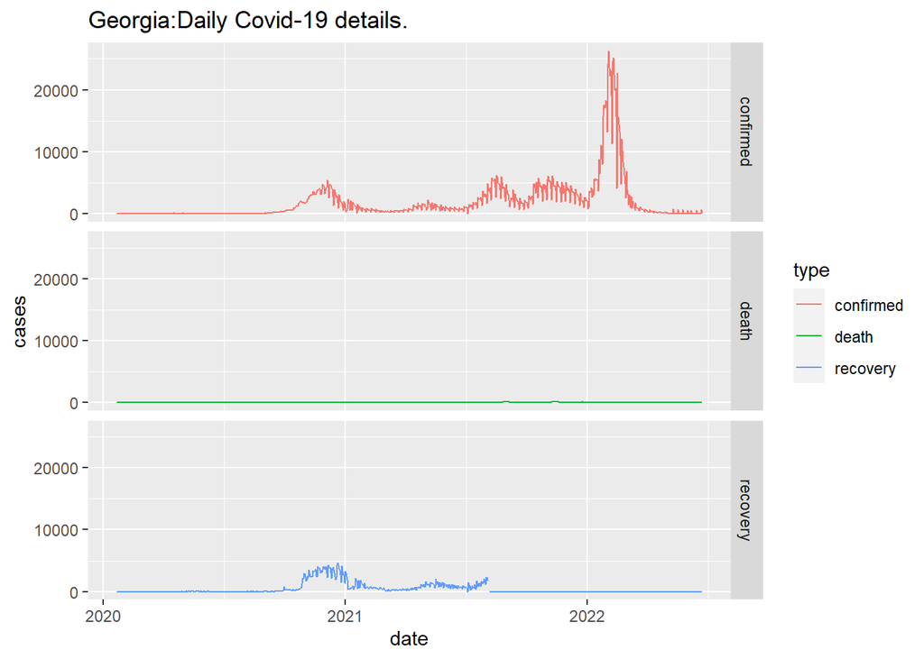

Figure 8:Time series plot of Coronavirus cases.

According to above figure 8 it can be clearly seen that minimum number of patients has died comparing with number of coronavirus confirmed patients. Majority of coronavirus confirmed patients has recovered from 2020 to middle of 2021.

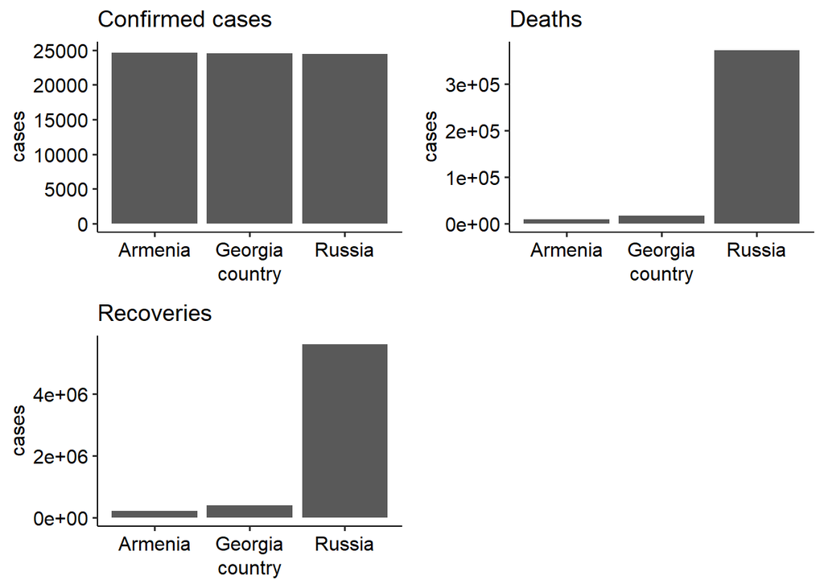

Here we can see as summary of all the confirmed, death, recovery cases.

# 3. Comparison with neighboring countries.

## 3.1 Georgia compare with Russia, Armenia and Azerbaijan.

**Russia:**

- Russia, the largest country in the world, occupies one-tenth of all the land on Earth. It spans 11 time zones across two continents (Europe and Asia) and has coasts on three oceans (the Atlantic, Pacific, and Arctic). The Russian landscape varies from desert to frozen coastline, tall mountains to giant marshes.

**Armenia:**

- Armenia is a landlocked country in Southwestern Asia or Eurasia. It is situated at the gateway between Western Asia and Eastern Europe and bordered by Azerbaijan, Georgia, Iran, and Turkey. Located in the Lesser Caucasus Mountains, Armenia is a mountainous region with fast-flowing rivers.

**Azerbaijan:**

- Azerbaijan is a landlocked country in Southwestern Asia located at the crossroads of Eastern Europe and Western Asia. It is bounded by the Caspian Sea, Russia, Georgia, Armenia, and Iran. The government system is a republic; the chief of state is the president, and the head of government is the prime minister.

### 3.1.1 Comparison with confirmed.

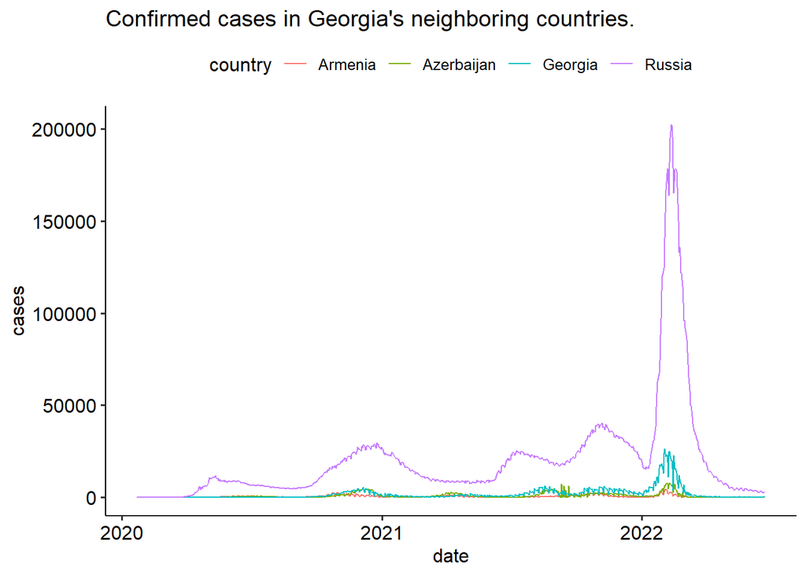

Figure 09: Comparing Time series plots of confirmed Coronavirus cases with neighboring countries.

By considering figure 9 we can see that daily Coronavirus confirmed cases in Georgia is less than daily Coronavirus confirmed casesin Russia and greater than daily Coronavirus confirmed cases in Armenia and Azerbaijan.But upto 2022 Georgia, Armenia and Azerbaijan shows approximately equal Coronavirus confirmed cases in per day.

### 3.1.2 Comparison with recovered.

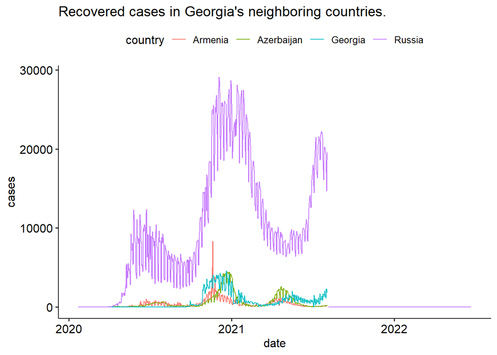

Figure 10: Compairing Time series plots of recovered Coronavirus cases with neighboring countries.

Using figure 10 we can say that recovered coronavirus cases in Georgia is less than Russia.Also Armenia, Azerbaijan, Georgia shows approximately equal coronavirus recovered cases in per day.

### 3.1.3 Comparison with deaths.

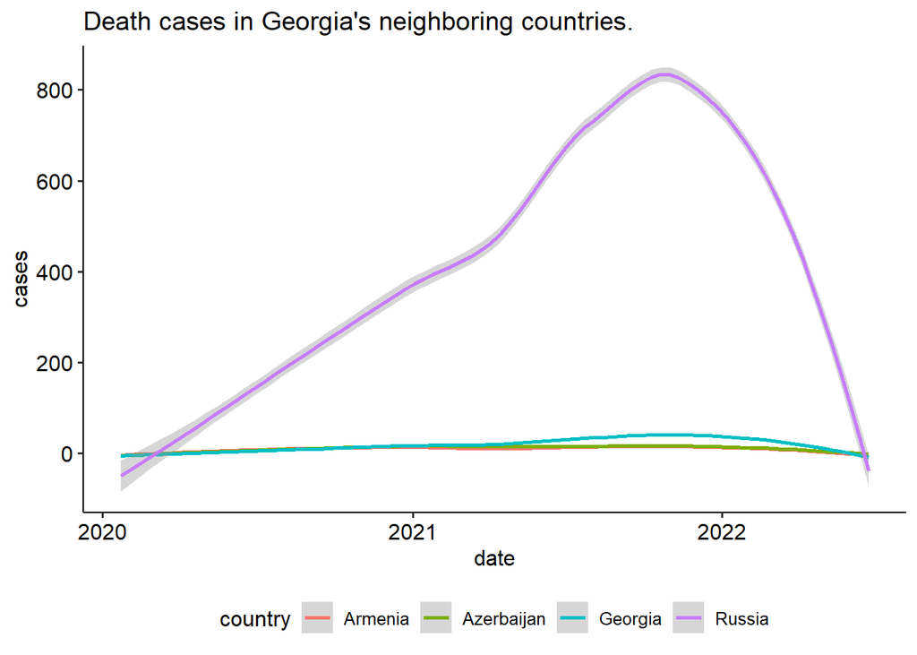

Figure 11: Comparing Time series plots of Coronavirus deaths with neighboring countries.

# 4. Discussion and Conclusion

## 4.1 Discussion

Main objective of this analysis is to get an idea about coronavirus effect of the country Georgia. So that using the data from the coronavirus repository (R package) has been used to do the analysis. This data set has been considered on from 22.01.2020 to 23.06.2022 time period. In this analysis we are considering three types of cases which are coronavirus confirmed cases, recovered cases and death cases.In recovered cases there were negative values and had to filter them out to show them as zero cases. And also to do the analysis with comparisons I have used three neighboring countries,which are Russia, Armenia and Azerbaijan.The reason for not choosing the Turkey as neighboring country that that results will highly differ from the Georgia.

# 5. References

- https://en.wikipedia.org/wiki/Georgia_(country)
- https://climateknowledgeportal.worldbank.org/country/georgia/climate-data-historical#
- https://kids.nationalgeographic.com/geography/countries/article/russia#
- https://globaledge.msu.edu/countries/armenia#
- https://globaledge.msu.edu/countries/azerbaijan#